# Reproducable Research Project 1

Ashton Chevallier

Thursday, April 16, 2015

## Loading and preprocessing the data

1. Download and unzip data  
   If you don’t have in your wd, download it and unzip it.

```r
if(!file.exists("activity.csv")){
    if(!file.exists("activity.zip")){
        download.file("https://d396qusza40orc.cloudfront.net/repdata%2Fdata%2Factivity.zip"
                      ,destfile = "activity.zip")
    }
    unzip("activity.zip")
}
```

2. Read data in data frame using read.csv

```r
if(!exists("dataRaw")) {
    dataRaw <- read.csv("activity.csv")
}
```

```r
library(ggplot2)
library(dplyr)
#Transform Factor Dates to Date
days <- as.Date(dataRaw[,2])
steps <- dataRaw[,1]

#Create subset of NA Free data
data <- dataRaw[!is.na(dataRaw[,1]),]
```

### What is the total number of steps taken per day?

1. Calculate the total number of steps taken per day

```r
dailySteps <- group_by(data,date) %>% summarize(steps=sum(steps))
```

2. Make a histogram of total steps taken each day

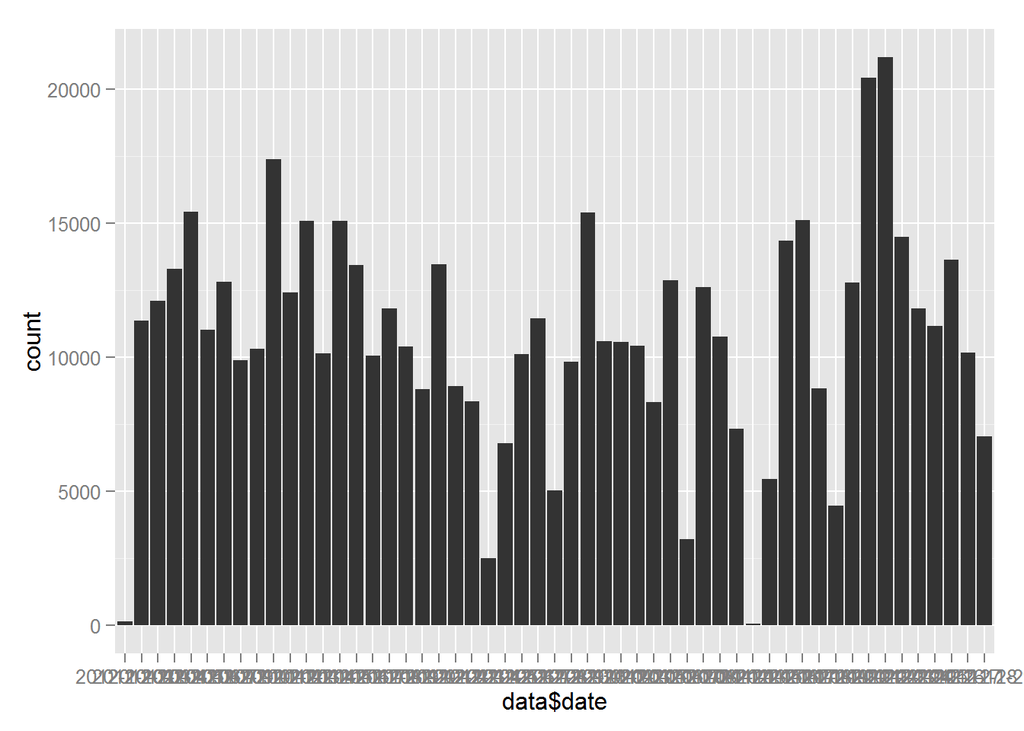

```r
qplot(data$date, data=data, weight=steps, geom="histogram",binwidth = 1)
```

3. Calculate and report the mean and median of the total number of steps taken per day

```r
summary(dailySteps$steps)
```

```
##    Min. 1st Qu.  Median    Mean 3rd Qu.    Max.
##      41    8841   10760   10770   13290   21190
```

### What is the daily activity pattern?

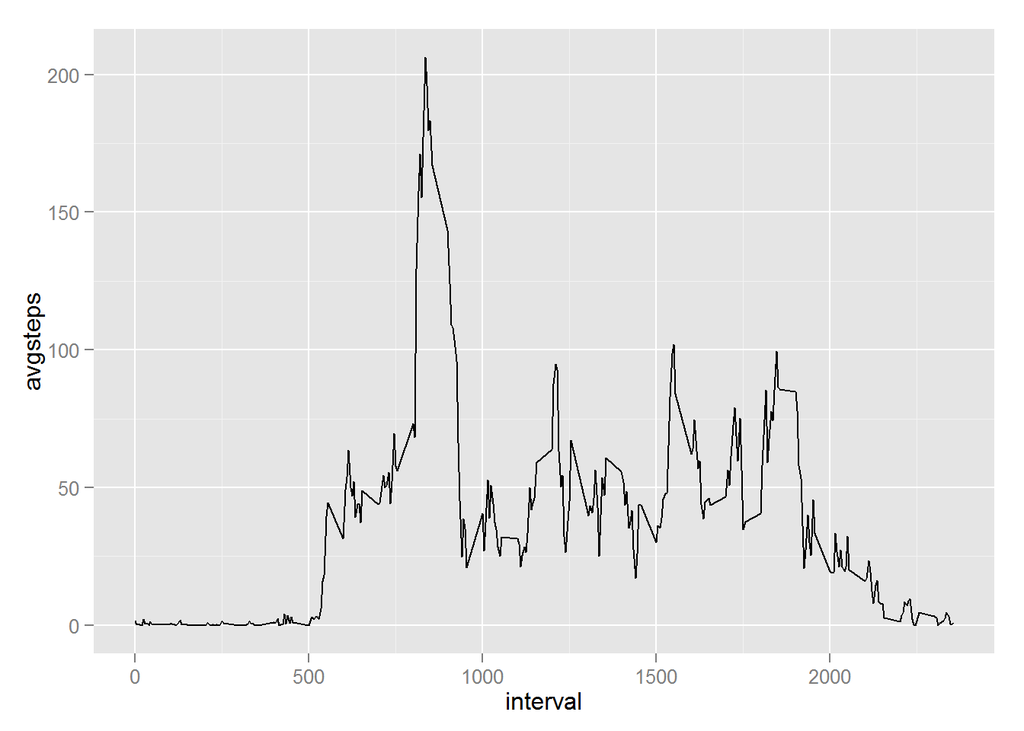

```r
avgSteps <- group_by(data,interval) %>% summarize(avgsteps=mean(steps))
qplot(data=avgSteps,x=interval,y=avgsteps,geom="line")
```

2. Find interval with maximum average steps

```r
intervalSteps <- group_by(data,interval) %>% summarize(totalsteps=sum(steps))
maxInterval <- which(intervalSteps$totalsteps==max(intervalSteps$totalsteps))
cbind(maxInterval,intervalSteps[maxInterval,])
```

```
##   maxInterval interval totalsteps
## 1         104      835      10927
```

### Imputing Missing Values

1. Calculate the total missing values in the dataset (IE. total rows with NA)

```r
count(dataRaw[is.na(dataRaw),])
```

```
## Source: local data frame [1 x 1]
##
##      n
## 1 2304
```

2. To fill in these missing values, we will be using the average interval steps. It’s as good as method as any, and we already calculated it earlier.
3. Now we’ll use a loop to fill in the data.

```r
narows <- which(is.na(dataRaw))
zdata <-dataRaw
for(i in narows){
  zdata[i,1] <- avgSteps[which(avgSteps$interval==zdata[i,3]),2]
}
summary(is.na(zdata))
```

```
##    steps            date          interval
##  Mode :logical   Mode :logical   Mode :logical
##  FALSE:17568     FALSE:17568     FALSE:17568
##  NA's :0         NA's :0         NA's :0
```

4. Plot Histogram of new filled in data, then output the summary

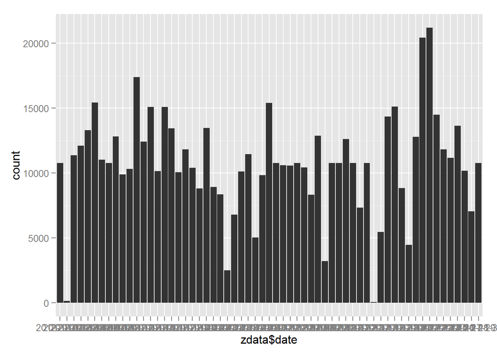

```r
qplot(zdata$date, data=zdata, weight=steps, geom="histogram",binwidth = 1)
```

```r
summary(zdata$steps)
```

```
##    Min. 1st Qu.  Median    Mean 3rd Qu.    Max.
##    0.00    0.00    0.00   37.38   27.00  806.00
```

### Are there differences in activity patterns between weekdays and weekends?

1. Create new variable weekday to the filled in dataset

```r
#Helper Function to make weekday or weekend
weekend <- function(x) {
  if(x=='Sunday' | x=='Saturday') {y <- 'Weekend'}
  else {y <- 'Weekday'}
  y
  }

#Mutate to make new variable
zdata <- mutate(zdata, Weekday = weekdays(as.Date(date)))
zdata$Weekday <- sapply(zdata$Weekday,FUN=weekend)
```

2. Make panel plot of Weekdays vs. Weekends

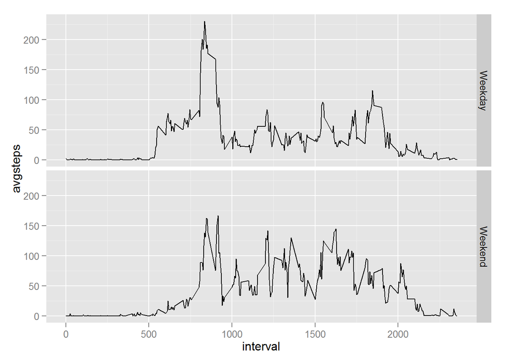

```r
avgWeekdaySteps <- group_by(zdata,Weekday,interval) %>% summarize(avgsteps=mean(steps))
qplot(data=avgWeekdaySteps,x=interval,y=avgsteps,geom="line", facets = Weekday ~.)
```